# Anova - ćw5

Aby uzyskać poprawne założenia do testu ANOVA wykonujemy transformacje logarytmiczną oraz ponawiamy wcześniejsze analizy.

```r
#2.4
Cancer_log <- Cancer
Cancer_log$Survival <- log(Cancer_log$Survival, 10)
Cancer_log_ANOVA <- aov(Survival~Organ, data=Cancer_log)
summary(Cancer_log_ANOVA)
```

```
##             Df Sum Sq Mean Sq F value  Pr(>F)
## Organ        4  4.618  1.1546   4.286 0.00412 **
## Residuals   59 15.894  0.2694
## ---
## Signif. codes:  0 '***' 0.001 '**' 0.01 '*' 0.05 '.' 0.1 ' ' 1
```

Wartość p-value jest mniejsza od 0.05 zatem odrzucamy hipotezę zerową.

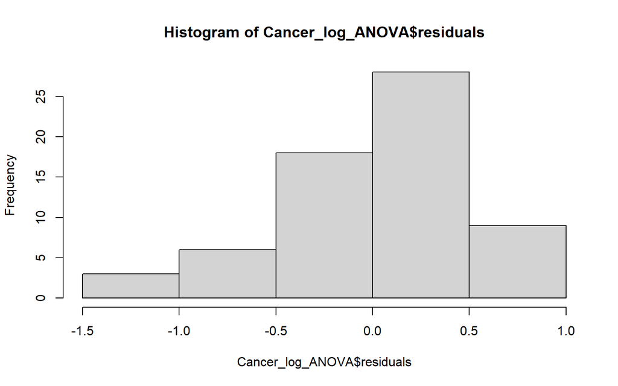

```r
hist(Cancer_log_ANOVA$residuals)
```

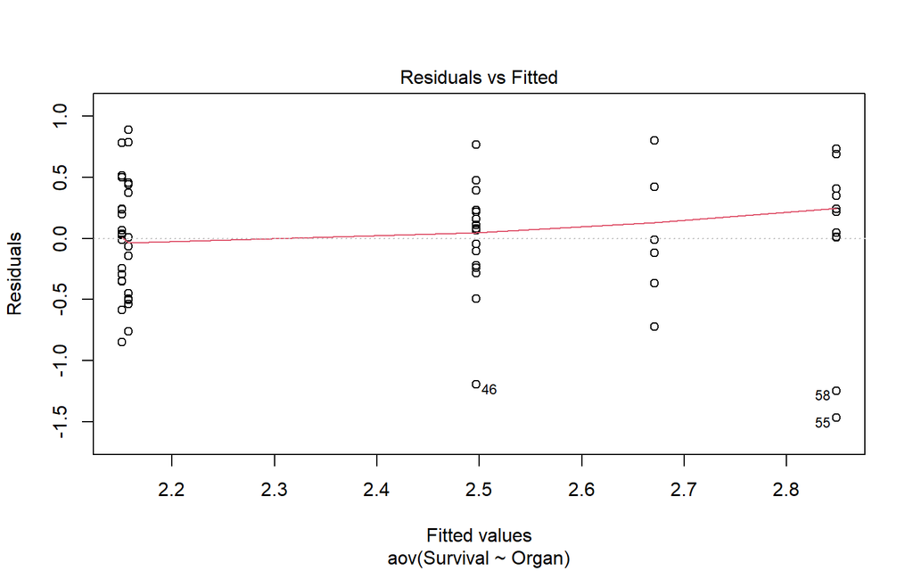

```r
plot(Cancer_log_ANOVA, 1)
```

Po transformacji wariancje są już zbliżone.

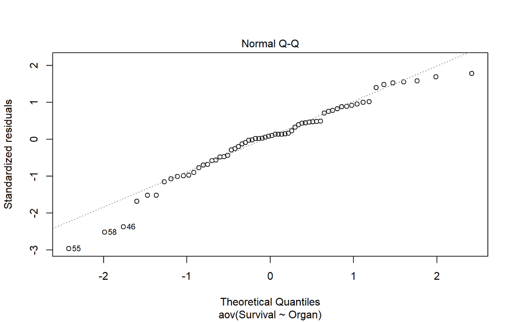

```r
plot(Cancer_log_ANOVA, 2)
```

Rozkład wartości resztowych również zbliżył się do normalnego.

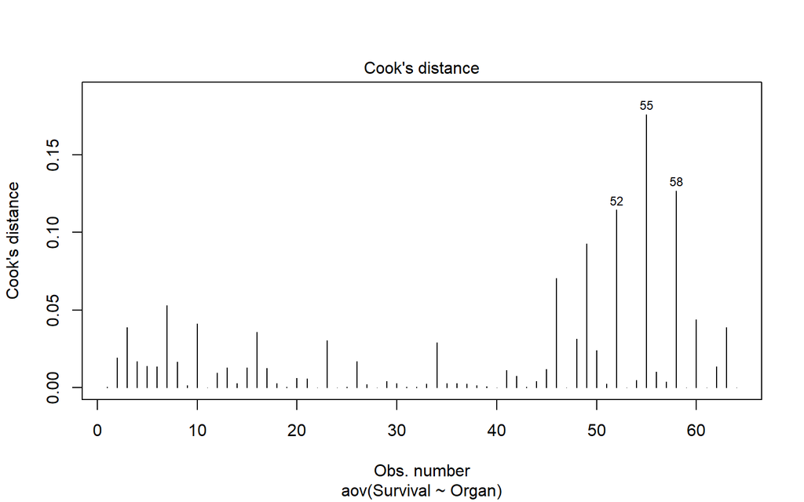

```r
plot(Cancer_log_ANOVA, 4)
```

```r
Tukey <- TukeyHSD(Cancer_log_ANOVA, header = TRUE, sep = "\t")

data.frame(Tukey$Organ[Tukey$Organ[,4]<0.05,4])
```

```
##                 Tukey.Organ.Tukey.Organ...4....0.05..4.
## Bronchus-Breast                             0.008335192
## Stomach-Breast                              0.015813189
```

Największe różnice w przeżywalności występują między:

- Bronchus-Breast
- Stomach-Breast

Gdyż wartość p-value dla nich jest mniejsza od 0.05.

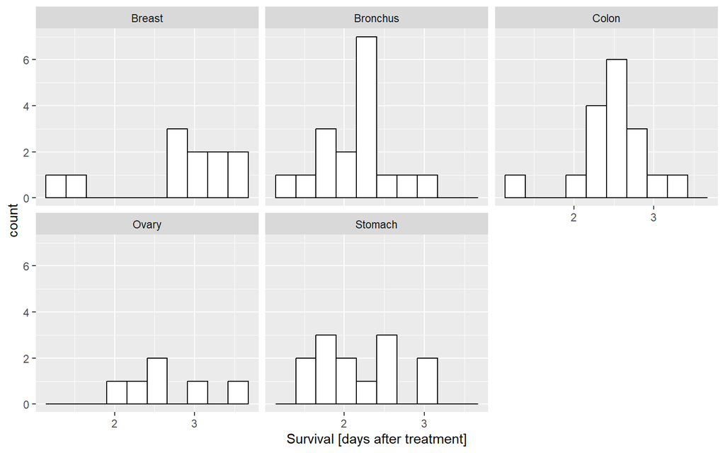

```r
ggplot(Cancer_log, aes(x = Survival)) +
  geom_histogram(bins=10, colour="black", fill="white") +
  facet_wrap(~Organ, scales="fixed") +
  xlab("Survival [days after treatment]")
```

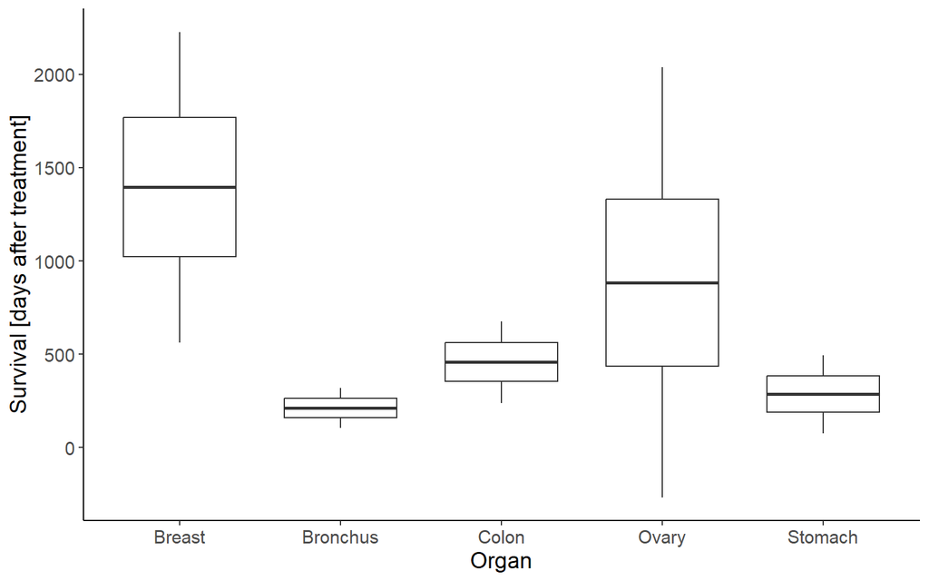

```r
#2.4
ggplot(data = Cancer_ANOVA, mapping = aes(x = Organ,
                                        y = Survival)) +
  stat_summary(fun.data=Mean_SE_95CI, geom="boxplot", width=0.7) +
  theme_classic() + theme(text = element_text(size = 14)) +
  labs(x = "Organ", y = "Survival [days after treatment]")
```

```r
#2.5
kruskal.test(Survival~Organ, data=Cancer_log)
```

```
##
##  Kruskal-Wallis rank sum test
##
## data:  Survival by Organ
## Kruskal-Wallis chi-squared = 14.954, df = 4, p-value = 0.004798
```

Wartość p-value jest mniejsza od 0.05 zatem odrzucamy hipotezę zerową i przyjmujemy alternatywną.

Po wykonanej analizie z użyciem testów ANOVA i Kruskala-Wallisa uzyskujemy argument za odrzuceniem hipotezy zerowej i przyjęciem alternatywnej. Przeżywalność przy chorobach nowotworowych atakujących różne narządy różni się.